# 2.2. Joint Analysis of Methylation and Genotype Data

Andrey A Shabalin

2017-02-21

# 1 Joint Analysis of Methylation and Genotype Data

Single nucleotide polymorphisms (SNPs) can create and destroy CpGs. As methylation (measured with MBD-seq) can occur only at CpGs, SNPs can directly affect the number of CpGs in a neighborhood and thus affect methylation measurements.

[RaMWAS](http://www.bioconductor.org/packages/devel/bioc/html/ramwas.html) can account for a possible effect of SNPs by testing the following model:

$$\mu_i = \beta_0 + outcome * \beta_1 + {outcome} * {SNP}_i * \beta_2 + {SNP}_i \beta_3 + \gamma * { cvrt} + \epsilon$$

where

- $\mu_i$ – methylaiton measurement for $i$-th CpG.
- $outcome$ – phenotype of interest.
- $SNP_i$ – the SNP values (0/1/2 or dosages for imputed genotype) at the $i$-th CpG.
- $cvrt$ – covariates and the principal components.
- $\epsilon$ – noise.

## 1.1 Input data

For SNP-corrected analysis RaMWAS requres the usual input as for steps 4 and 5 with additional SNP matrix.

The SNP data must have the same dimensions as the coverage matrix, with SNPs matching the CpGs.

Below we provide sample code for this analysis.

### 1.1.1 Create data matrix from external data

We produce the following artificial files.

- `CpG_locations.*` – filematrix with the location of the CpGs that passed the threshold.  
  It must have two columns with integer values – chromosome number and location (`chr` and `position`).
- `CpG_chromosome_names.txt` – file with chromosome names (factor levels) for the integer column `chr` in the location filematrix.
- `Coverage.*` – filematrix with the data for all samples and all locations.  
  Each row has data for a single sample. Row names must be sample names.  
  Each column has data for a single location. Columns must match rows of the location filematrix.
- ’SNPs.*’ – filematrix with genotype data, matching the coverage matrix.

First, we load the package and set up a working directory. One may choose to set the project directory `dr` to a more convenient location when running this code.

```r
library(ramwas)

# work in a temporary directory
dr = paste0(tempdir(), "/simulated_matrix_data")
dir.create(dr, showWarnings = FALSE)
cat(dr,"\n")
```

```
## D:\Mapped_to_boot_drive\Temp\Rtmpgb7unN/simulated_matrix_data
```

Let the sample data matrix have 1000 samples and 100,000 variables.

```r
nsamples = 1000
nvariables = 100000
```

For these 1000 samples we generate a data frame with age and sex phenotypes and a batch effect covariate.

```r
covariates = data.frame(
    sample = paste0("Sample_",seq_len(nsamples)),
    sex = seq_len(nsamples) %% 2,
    age = runif(nsamples, min = 20, max = 80),
    batch = paste0("batch",(seq_len(nsamples) %% 3))
)
pander(head(covariates))
```

| sample | sex | age | batch |
| --- | --- | --- | --- |
| Sample_1 | 1 | 71.5 | batch1 |
| Sample_2 | 0 | 35.8 | batch2 |
| Sample_3 | 1 | 60.4 | batch0 |
| Sample_4 | 0 | 64.5 | batch1 |
| Sample_5 | 1 | 28.4 | batch2 |
| Sample_6 | 0 | 26.3 | batch0 |

Next, we create the genomic locations for 100,000 variables.

```r
temp = cumsum(sample(20e7 / nvariables, nvariables, replace = TRUE) + 0)
chr      = as.integer(temp %/% 1e7) + 1L
position = as.integer(temp %% 1e7)

locmat = cbind(chr = chr, position = position)
chrnames = paste0("chr", 1:22)
pander(head(locmat))
```

| chr | position |
| --- | --- |
| 1 | 1717 |
| 1 | 2245 |
| 1 | 3591 |
| 1 | 5074 |
| 1 | 5355 |
| 1 | 5565 |

Now we save locations in a filematrix and create a text file with chromosome names.

```r
fmloc = fm.create.from.matrix(
            filenamebase = paste0(dr,"/CpG_locations"),
            mat = locmat)
close(fmloc)
writeLines(con = paste0(dr,"/CpG_chromosome_names.txt"), text = chrnames)
```

Finally, we create methylation and SNP matrices and populate them.

```r
fmm = fm.create(paste0(dr,"/Coverage"), nrow = nsamples, ncol = nvariables)
fms = fm.create(paste0(dr,"/SNPs"), nrow = nsamples, ncol = nvariables, size = 1, type = 'integer')

# Row names of the matrices are set to sample names
rownames(fmm) = as.character(covariates$sample)
rownames(fms) = as.character(covariates$sample)

# The matrices are filled, 2000 variables at a time
byrows = 2000
for( i in seq_len(nvariables/byrows) ){ # i=1
    ind = (1:byrows) + byrows*(i-1)

    snps = rbinom(n = byrows * nsamples, size = 2, prob = 0.2)
    dim(snps) = c(nsamples, byrows)
    fms[,ind] = snps

    slice = double(nsamples*byrows)
    dim(slice) = c(nsamples, byrows)
    slice[,  1:225] = slice[,  1:225] + covariates$sex / 75 / sd(covariates$sex)
    slice[,101:116] = slice[,101:116] + covariates$age / 24 / sd(covariates$age)
    slice = slice +
            ((as.integer(factor(covariates$batch))+i) %% 3) / 200 +
            snps/2 +
            runif(nsamples*byrows)/2
    fmm[,ind] = slice;
}
close(fms)
close(fmm)
```

## 1.2 Association testing with and without correction for SNPs

Let us test for association between variables in the data matrix and the sex covariate (`modeloutcome` parameter) correcting for batch effects (`modelcovariates` parameter). Save top 20 results (`toppvthreshold` parameter) in a text file.

```r
param = ramwasParameters(
    dircoveragenorm = dr,
    covariates = covariates,
    modelcovariates = "batch",
    modeloutcome = "sex",
    toppvthreshold = 20,
    fileSNPs = 'SNPs'
)
```

First, we perform the usual analysis without correction for SNPs.

```r
ramwas5MWAS(param)
```

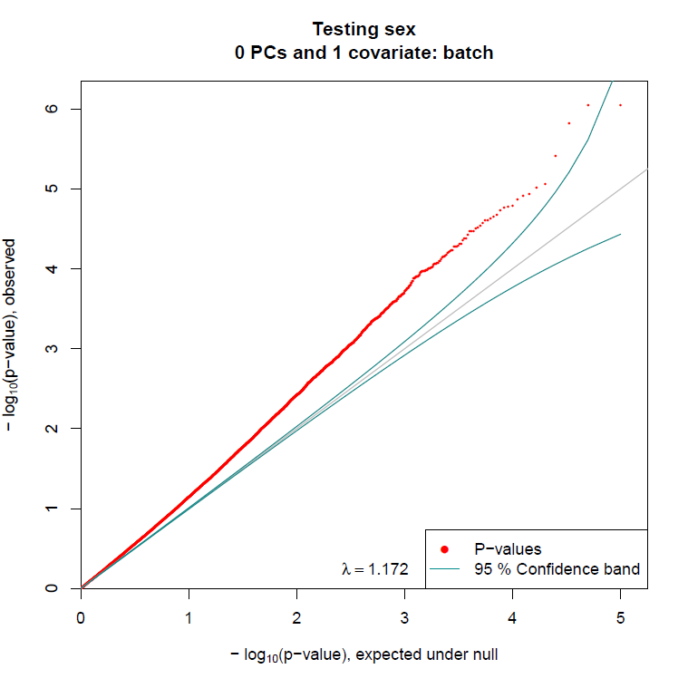

The analysis with correction for SNPs is next:

```r
ramwasSNPs(param)
```

The QQ-plot shows better enrichment with significant p-values.

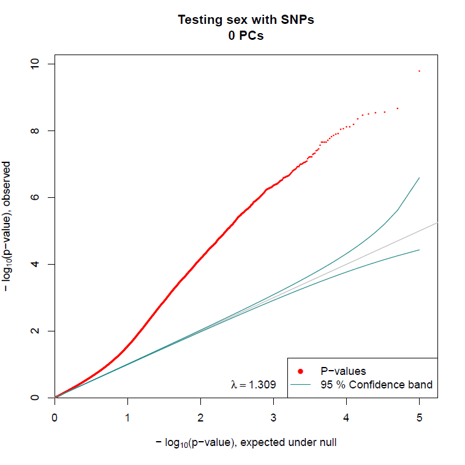

The top finding are saved in the text files for regular and SNP-corrected MWAS:

```r
# Get the directory with testing results
pfull = parameterPreprocess(param)
toptbl = read.table(
                paste0(pfull$dirmwas,"/Top_tests.txt"),
                header = TRUE, sep = "\t",
                stringsAsFactors = FALSE)
pander(head(toptbl,10))
```

| chr | position | tstat | pvalue | qvalue |
| --- | --- | --- | --- | --- |
| chr9 | 2617691 | -5.01 | 6.6e-07 | 0.0256 |
| chr8 | 6014514 | 4.89 | 1.2e-06 | 0.0256 |
| chr6 | 145308 | 4.88 | 1.22e-06 | 0.0256 |
| chr4 | 8025183 | 4.88 | 1.24e-06 | 0.0256 |
| chr4 | 243805 | 4.87 | 1.28e-06 | 0.0256 |
| chr2 | 2142296 | 4.79 | 1.89e-06 | 0.0316 |
| chr3 | 6117859 | 4.71 | 2.76e-06 | 0.0377 |
| chr3 | 2057591 | 4.7 | 3.02e-06 | 0.0377 |
| chr10 | 5957154 | 4.67 | 3.4e-06 | 0.0378 |
| chr9 | 2047081 | 4.63 | 4.05e-06 | 0.0394 |

```r
toptbl = read.table(
                paste0(pfull$dirSNPs,"/Top_tests.txt"),
                header = TRUE, sep = "\t",
                stringsAsFactors = FALSE)
pander(head(toptbl,10))
```

| chr | position | tstat | pvalue | qvalue |
| --- | --- | --- | --- | --- |
| chr10 | 2089075 | 21.7 | 6.05e-10 | 3.15e-05 |
| chr8 | 1968601 | 21.4 | 7.98e-10 | 3.15e-05 |
| chr3 | 4151254 | 21.2 | 9.46e-10 | 3.15e-05 |
| chr4 | 4030406 | 20.6 | 1.77e-09 | 4.42e-05 |
| chr6 | 4155598 | 19.2 | 6.36e-09 | 0.000127 |
| chr1 | 219106 | 18.8 | 9.91e-09 | 0.000165 |
| chr8 | 1959957 | 18.3 | 1.5e-08 | 0.000202 |
| chr2 | 8140524 | 18.3 | 1.61e-08 | 0.000202 |
| chr2 | 4175438 | 18.1 | 1.89e-08 | 0.00021 |
| chr4 | 72164 | 17.8 | 2.43e-08 | 0.000229 |